# DATA 605 HW 9

Josh Iden

2022-10-23

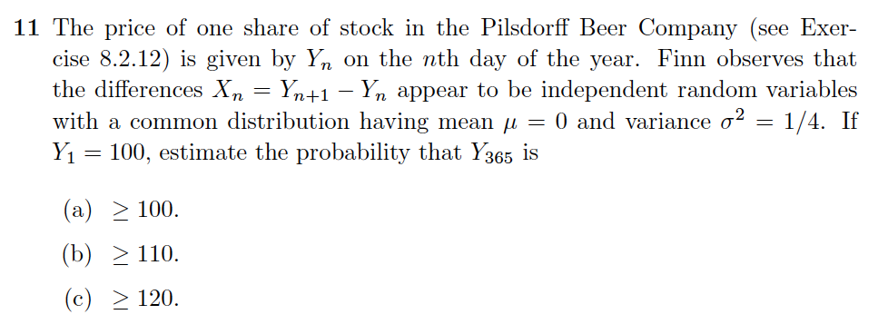

```r
n = 364 #rest of year
m = 0 #mean
EX = 100 #expected value
var = 1/4 #σ^2
barvar = n * var
barsd = sqrt(barvar)
```

$>= 100$:

```r
z = (100 - EX) / barsd
pnorm(z, lower.tail=FALSE)
```

```
## [1] 0.5
```

$>= 110$:

```r
z = (110 - EX) / barsd
pnorm(z, lower.tail=FALSE)
```

```
## [1] 0.1472537
```

$>= 120$

```r
z = (120 - EX) / barsd
pnorm(z, lower.tail=FALSE)
```

```
## [1] 0.01801584
```

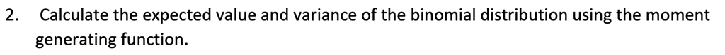

Given the binomial PMF:

$P_x = (\frac{n}{x})p^x(1 - p)^{n - x}$

Where $P_x$ is the probability of $x$ successes within $n$ trials and () is the number of combinations of $x$ in $n$, and the Moment Generating Function:

$M_x(t) = E(e^{tx})$

Which is the expected value of $x$ at moment $t$, combining with the PMF of the binomial distribution yields the functions:

$M(t) = \sum^{n}_{x=0}e^{tx} * (\frac{n}{x})p^x(1 - p)^{n - x}$

Which simplifies to $M(t) = (pe^t + 1 - p)^n$ when $t$ is a real number.

To get the first moment, take the first derivative and evaluate at 0.

First derivative: $M'(t) = npe^t(pe^t - p + 1)^{n-1}$

Evaluate at 0: $M'(0) = npe^0(pe^0 - p + 1)^{n-1} \Longrightarrow np(p - p + 1)^{n-1} \Longrightarrow np(1)^{n-1} \Longrightarrow np$

So the expected value is $np$.

$M"(t) = npe^t(pe^t - p + 1)^{n-2}(npe^t - p + 1)$

Evaluate at 0:

$M"(0) = npe^0(pe^0 - p + 1)^{n-2}(npe^0 - p + 1) \Longrightarrow np(np - p + 1)$

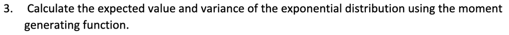

For the exponential distribution, given the PDF:

$f(x) = λe^{-λx}$

And the Moment Generating Function:

$M(t)=\int^\inf_0 e^{tx}*λ e^{-λ x} = \frac{λ}{λ-t}, t < λ$

We take the first derivative for the expected value at 0:

$M'(t) = \frac{λ}{(λ-t)^2} \Longrightarrow$

$E[X] = M'(0) = \frac{λ}{(λ-0)^2} \Longrightarrow \frac{λ}{λ^2}\Longrightarrow \frac{1}{λ}$

So the expected value is $\frac{1}{λ}$.

We take the second derivative for the variance to get the second moment of the distribution:

$E[X^2] = M''(t) = \int^∞_0 t^2λε^{-λχ}= \frac{2}{λ^2}$

And the variance of the continuous random variable is caluclated as:

$VAR[X] = E[X^2] - E[X]^2 \Longrightarrow$

$VAR[X] = \frac{2}{λ^2}- \frac{1}{λ^2} \Longrightarrow \frac{1}{λ^2}$

So the variance is $\frac{1}{λ^2}$.